# eIF3d/eIF3e Knockdown TE Changes (With/Without Spike-in) vs Literature

Kate

2026-07-21

# Purpose

**All “ours” si3d/si3e TE numbers in this notebook (both with-spike and no-spike legs, in every table and plot) are 1+4hr time-regressed normoxia results** — i.e. `deFunction_time_normalized()` fit on the 1hr+4hr normoxia samples jointly with `hours` as a batch covariate, not a single-timepoint result. This is noted here, in the notebook text, rather than in the plots themselves — the plot labels/titles below say “normoxia” only, without “1+4hr”, to keep them concise.

Fourth notebook in the spike-in vs literature comparison subsection. Extends `03_bar_te_si3d_si3e_vs_literature.Rmd`’s final combined eIF3d/eIF3e plots to add a **no-spike-in** bar right after each **with-spike-in** bar for our own si3d/si3e data (matching the with/without spike-in comparison style used in notebooks 01/02, now applied to the knockdown-vs-sictrl TE comparison instead of the hypoxia-vs-normoxia one).

**No saved no-spike-in si3d/si3e TE (1+4hr) file exists anywhere in the repo.** Checked: `analyzing_spikeins.Rmd` computes per-timepoint (1/4/24hr) si3d/si3e no-spike TE in memory only (`si3d_nospike_results`, `si3e_nospike_results` — no `write_csv`). `si3e_si3d_normoxia_1and4hr_timecourse.Rmd` computes the exact 1+4hr time-regressed no-spike TE we need (`res_te_si3d_nospike_1and4hr`, `res_te_si3e_nospike_1and4hr`) for its density-plot comparison, but also never saves it to a file. So unlike every other “with-spike” number in this subsection, **this leg is computed fresh here** — following that notebook’s exact method — and saved, so it becomes reusable going forward.

- **Method, copied exactly from `si3e_si3d_normoxia_1and4hr_timecourse.Rmd`:** `deFunction_time_normalized(control_condition = "si3d"/"si3e", test_condition = "sictrl", mode = "TE")`, with `spikeInMatrix = NULL, keepSpikes = NULL` and a `createNormMatrix(..., spikein = NULL)` normalization matrix for the no-spike leg. Same `control_condition`/`test_condition` assignment as the saved with-spike files used in notebook 03 — log2(sictrl/si3d) or log2(sictrl/si3e) — so **no sign flip is needed** between the with-spike and no-spike legs; both already share our positive-means-promoted convention.

```r
library(here)
library(tidyverse)
library(DESeq2)
library(ggtext)
```

```r
source(here("code/functions.R"))
cat("Loaded deFunction_time_normalized, createNormMatrix\n")
```

```
## Loaded deFunction_time_normalized, createNormMatrix
```

# Load with-spike-in si3d/si3e TE (1+4hr, precomputed, reused from notebook 03)

```r
with_spike_files <- tribble(
  ~treatment, ~file,
  "si3d", "translation_categories_si3d_vs_sictrl_normoxia_1and4hr.csv",
  "si3e", "te_si3e_vs_sictrl_normoxia_1and4hr.csv"
)

stopifnot("One or more si3d/si3e 1+4hr with-spike TE files missing" =
  all(file.exists(here("output", with_spike_files$file))))

with_spike_data <- pmap(with_spike_files, function(treatment, file) {
  read_csv(here("output", file), show_col_types = FALSE) %>%
    dplyr::select(gene_id, log2FoldChange = te_lfc, padj = te_padj) %>%
    mutate(treatment = treatment, spike_status = "With spike-in")
}) %>% list_rbind()

for (i in seq_len(nrow(with_spike_files))) {
  n <- sum(with_spike_data$treatment == with_spike_files$treatment[i])
  cat(with_spike_files$treatment[i], "with-spike 1+4hr TE rows:", n, "\n")
}
```

```
## si3d with-spike 1+4hr TE rows: 11879
## si3e with-spike 1+4hr TE rows: 11879
```

# Compute no-spike-in si3d/si3e TE (1+4hr) — not previously saved

```r
allCounts <- read_csv(here("output", "human_allCounts_raw.csv")) %>%
  column_to_rownames("gene_id")
metadata <- read_csv(here("output", "metadata_clean.csv"))
cat("allCounts:", dim(allCounts), "\n")
```

```
## allCounts: 11879 107
```

```r
cat("Metadata:", nrow(metadata), "samples\n")
```

```
## Metadata: 107 samples
```

```r
run_nospike_te <- function(treatment_val) {
  metadata_tp <- metadata %>%
    filter(condition == "normoxia") %>%
    filter(treatment %in% c("sictrl", treatment_val)) %>%
    filter(hours %in% c(1, 4)) %>%
    mutate(comparison_variable = treatment)
  metadata_tp$hours <- as.factor(metadata_tp$hours)

  counts_tp <- allCounts[, metadata_tp$sample_name]

  normMatrix_nospike <- createNormMatrix(
    allCounts = counts_tp,
    metadata = metadata_tp,
    control_condition = treatment_val,
    spikein = NULL,
    keepSpikes = NULL
  )

  deFunction_time_normalized(
    countsMatrix = counts_tp,
    allCounts_Norm = normMatrix_nospike,
    metadata = metadata_tp,
    control_condition = treatment_val,
    test_condition = "sictrl",
    spikeInMatrix = NULL,
    keepSpikes = NULL,
    mode = "TE"
  )
}

res_te_si3d_nospike <- run_nospike_te("si3d")
```

```
## Using standard DESeq2 normalization (no spike-ins)
```

```
## Size factors estimated using standard DESeq2 method
```

```
## DESeq2 normalization complete. Matrix dimensions: 11879 genes x 24 samples
```

```
##
## === Running deFunction in TE mode ===
```

```
## Control: si3d vs Test: sictrl
```

```
## Using time-adjusted TE design: ~ hours + Condition + SeqType + Condition:SeqType
```

```
## [1] "Intercept"                   "hours_4_vs_1"
## [3] "Condition_sictrl_vs_si3d"    "SeqType_ribo_vs_rna"
## [5] "Conditionsictrl.SeqTyperibo"
```

```
## using 'apeglm' for LFC shrinkage. If used in published research, please cite:
##     Zhu, A., Ibrahim, J.G., Love, M.I. (2018) Heavy-tailed prior distributions for
##     sequence count data: removing the noise and preserving large differences.
##     Bioinformatics. https://doi.org/10.1093/bioinformatics/bty895
```

```
## Analysis complete. Significant genes (padj < 0.05): 561
```

```r
res_te_si3e_nospike <- run_nospike_te("si3e")
```

```
## Using standard DESeq2 normalization (no spike-ins)
```

```
## Size factors estimated using standard DESeq2 method
```

```
## DESeq2 normalization complete. Matrix dimensions: 11879 genes x 23 samples
```

```
##
## === Running deFunction in TE mode ===
```

```
## Control: si3e vs Test: sictrl
```

```
## Using time-adjusted TE design: ~ hours + Condition + SeqType + Condition:SeqType
```

```
## [1] "Intercept"                   "hours_4_vs_1"
## [3] "Condition_sictrl_vs_si3e"    "SeqType_ribo_vs_rna"
## [5] "Conditionsictrl.SeqTyperibo"
```

```
## using 'apeglm' for LFC shrinkage. If used in published research, please cite:
##     Zhu, A., Ibrahim, J.G., Love, M.I. (2018) Heavy-tailed prior distributions for
##     sequence count data: removing the noise and preserving large differences.
##     Bioinformatics. https://doi.org/10.1093/bioinformatics/bty895
```

```
## Analysis complete. Significant genes (padj < 0.05): 1847
```

```r
no_spike_data <- bind_rows(
  res_te_si3d_nospike %>% dplyr::select(gene_id, log2FoldChange, padj) %>% mutate(treatment = "si3d"),
  res_te_si3e_nospike %>% dplyr::select(gene_id, log2FoldChange, padj) %>% mutate(treatment = "si3e")
) %>%
  mutate(spike_status = "No spike-in")

cat("si3d no-spike 1+4hr TE rows:", sum(no_spike_data$treatment == "si3d"), "\n")
```

```
## si3d no-spike 1+4hr TE rows: 11879
```

```r
cat("si3e no-spike 1+4hr TE rows:", sum(no_spike_data$treatment == "si3e"), "\n")
```

```
## si3e no-spike 1+4hr TE rows: 11879
```

```r
write_csv(res_te_si3d_nospike %>% dplyr::select(gene_id, log2FoldChange, padj) %>% dplyr::rename(te_lfc = log2FoldChange, te_padj = padj),
          here("output/spikein_literature_comparison/04_te_si3d_vs_sictrl_normoxia_nospike_1and4hr.csv"))
write_csv(res_te_si3e_nospike %>% dplyr::select(gene_id, log2FoldChange, padj) %>% dplyr::rename(te_lfc = log2FoldChange, te_padj = padj),
          here("output/spikein_literature_comparison/04_te_si3e_vs_sictrl_normoxia_nospike_1and4hr.csv"))
cat("Saved no-spike si3d/si3e 1+4hr TE results (first time this has been persisted anywhere in the repo)\n")
```

```
## Saved no-spike si3d/si3e 1+4hr TE results (first time this has been persisted anywhere in the repo)
```

## Computational checks

```r
te_data <- bind_rows(with_spike_data, no_spike_data)

stopifnot(
  "log2FoldChange must be finite" =
    all(is.finite(te_data$log2FoldChange[!is.na(te_data$log2FoldChange)])),
  "padj must be within [0, 1]" =
    all(te_data$padj >= 0 & te_data$padj <= 1, na.rm = TRUE)
)
cat("log2FoldChange/padj range checks passed\n")
```

```
## log2FoldChange/padj range checks passed
```

# Count significant genes (|log2FC| >= 0.5, padj < 0.05)

```r
lfc_cutoff <- 0.5
padj_cutoff <- 0.05

sig_counts_si3d_si3e_spike <- te_data %>%
  filter(!is.na(padj), padj < padj_cutoff, abs(log2FoldChange) >= lfc_cutoff) %>%
  mutate(Direction = if_else(log2FoldChange > 0, "Up", "Down")) %>%
  dplyr::count(treatment, spike_status, Direction, name = "n") %>%
  mutate(
    Direction = factor(Direction, levels = c("Up", "Down")),
    treatment = factor(treatment, levels = c("si3d", "si3e")),
    spike_status = factor(spike_status, levels = c("With spike-in", "No spike-in"))
  )

print(sig_counts_si3d_si3e_spike)
```

```
## # A tibble: 8 × 4
##   treatment spike_status  Direction     n
##   <fct>     <fct>         <fct>     <int>
## 1 si3d      No spike-in   Down         92
## 2 si3d      No spike-in   Up          230
## 3 si3d      With spike-in Down         12
## 4 si3d      With spike-in Up          426
## 5 si3e      No spike-in   Down        493
## 6 si3e      No spike-in   Up          679
## 7 si3e      With spike-in Down         17
## 8 si3e      With spike-in Up         5510
```

```r
write_csv(sig_counts_si3d_si3e_spike, here("output/spikein_literature_comparison/04_sig_te_counts_si3d_si3e_with_nospike.csv"))
cat("Saved combined with/without spike-in si3d/si3e TE sig gene counts\n")
```

```
## Saved combined with/without spike-in si3d/si3e TE sig gene counts
```

# Literature comparisons (same sources/numbers as notebook 03)

```r
up_dark <- "#D55E00"
down_dark <- "#0072B2"

lin_groups <- tribble(
  ~source, ~Direction, ~n,
  "Lin et al. 2020<br>(MCF-10A, si-eIF3e 72h,<br>RPF p<0.01 & mRNA p>0.01)", "Up", 220,
  "Lin et al. 2020<br>(MCF-10A, si-eIF3e 72h,<br>RPF p<0.01 & mRNA p>0.01)", "Down", 240
)

okubo_groups <- tribble(
  ~source, ~Direction, ~n,
  "Okubo et al. 2025<br>(human iPSC, EIF3D CRISPRi<br>day 3, padj<0.05 & |log2FC|>1)", "Down", 402,
  "Okubo et al. 2025<br>(human iPSC, EIF3D CRISPRi<br>day 3, padj<0.05 & |log2FC|>1)", "Up", 919
)

herrmannova_groups <- tribble(
  ~source, ~target, ~Direction, ~n,
  "Herrmannova et al. 2024<br>(HeLa, siEIF3D, padj<0.05,<br>no LFC threshold)", "eIF3d", "Up", 1040,
  "Herrmannova et al. 2024<br>(HeLa, siEIF3D, padj<0.05,<br>no LFC threshold)", "eIF3d", "Down", 931,
  "Herrmannova et al. 2024<br>(HeLa, siEIF3E, padj<0.05,<br>no LFC threshold)", "eIF3e", "Up", 622,
  "Herrmannova et al. 2024<br>(HeLa, siEIF3E, padj<0.05,<br>no LFC threshold)", "eIF3e", "Down", 558
)
```

# Combined plots: with/without spike-in ours vs all literature comparisons

Same design as notebook 03’s final plots: bar color = source (Okabe-Ito), label color = Up (vermillion) / Down (blue). Our si3d/si3e now contribute **two** rows each (with spike-in, then no spike-in immediately after), sharing the same hue since both represent “ours” for that target — only the axis label distinguishes spike status.

```r
lin_groups_labeled <- lin_groups %>% mutate(target = "eIF3e")
okubo_groups_labeled <- okubo_groups %>% mutate(target = "eIF3d")

our_si3d_si3e_labeled <- sig_counts_si3d_si3e_spike %>%
  mutate(
    target = recode(as.character(treatment), si3d = "eIF3d", si3e = "eIF3e"),
    source = paste0("**", as.character(treatment), " normoxia, ",
                     recode(as.character(spike_status), "With spike-in" = "with spike-in", "No spike-in" = "no spike-in"),
                     "**<br>(padj<0.05, |log2FC|>=0.5)")
  ) %>%
  dplyr::select(source, target, Direction, n)

target_levels <- c("eIF3d", "eIF3e")

all_source_levels <- c(
  "**si3d normoxia, with spike-in**<br>(padj<0.05, |log2FC|>=0.5)",
  "**si3d normoxia, no spike-in**<br>(padj<0.05, |log2FC|>=0.5)",
  "Okubo et al. 2025<br>(human iPSC, EIF3D CRISPRi<br>day 3, padj<0.05 & |log2FC|>1)",
  "Herrmannova et al. 2024<br>(HeLa, siEIF3D, padj<0.05,<br>no LFC threshold)",
  "**si3e normoxia, with spike-in**<br>(padj<0.05, |log2FC|>=0.5)",
  "**si3e normoxia, no spike-in**<br>(padj<0.05, |log2FC|>=0.5)",
  "Lin et al. 2020<br>(MCF-10A, si-eIF3e 72h,<br>RPF p<0.01 & mRNA p>0.01)",
  "Herrmannova et al. 2024<br>(HeLa, siEIF3E, padj<0.05,<br>no LFC threshold)"
)

source_colors <- c(
  "**si3d normoxia, with spike-in**<br>(padj<0.05, |log2FC|>=0.5)" = "#E69F00",
  "**si3d normoxia, no spike-in**<br>(padj<0.05, |log2FC|>=0.5)" = "#E69F00",
  "**si3e normoxia, with spike-in**<br>(padj<0.05, |log2FC|>=0.5)" = "#56B4E9",
  "**si3e normoxia, no spike-in**<br>(padj<0.05, |log2FC|>=0.5)" = "#56B4E9",
  "Okubo et al. 2025<br>(human iPSC, EIF3D CRISPRi<br>day 3, padj<0.05 & |log2FC|>1)" = "grey50",
  "Lin et al. 2020<br>(MCF-10A, si-eIF3e 72h,<br>RPF p<0.01 & mRNA p>0.01)" = "grey50",
  "Herrmannova et al. 2024<br>(HeLa, siEIF3D, padj<0.05,<br>no LFC threshold)" = "grey50",
  "Herrmannova et al. 2024<br>(HeLa, siEIF3E, padj<0.05,<br>no LFC threshold)" = "grey50"
)

all_vs_literature <- bind_rows(
  our_si3d_si3e_labeled,
  lin_groups_labeled,
  okubo_groups_labeled,
  herrmannova_groups
) %>%
  mutate(
    Direction = factor(Direction, levels = c("Up", "Down")),
    target = factor(target, levels = target_levels),
    source = factor(source, levels = all_source_levels)
  )

print(all_vs_literature)
```

```
## # A tibble: 16 × 4
##    source                                                 target Direction     n
##    <fct>                                                  <fct>  <fct>     <dbl>
##  1 **si3d normoxia, no spike-in**<br>(padj<0.05, |log2FC… eIF3d  Down         92
##  2 **si3d normoxia, no spike-in**<br>(padj<0.05, |log2FC… eIF3d  Up          230
##  3 **si3d normoxia, with spike-in**<br>(padj<0.05, |log2… eIF3d  Down         12
##  4 **si3d normoxia, with spike-in**<br>(padj<0.05, |log2… eIF3d  Up          426
##  5 **si3e normoxia, no spike-in**<br>(padj<0.05, |log2FC… eIF3e  Down        493
##  6 **si3e normoxia, no spike-in**<br>(padj<0.05, |log2FC… eIF3e  Up          679
##  7 **si3e normoxia, with spike-in**<br>(padj<0.05, |log2… eIF3e  Down         17
##  8 **si3e normoxia, with spike-in**<br>(padj<0.05, |log2… eIF3e  Up         5510
##  9 Lin et al. 2020<br>(MCF-10A, si-eIF3e 72h,<br>RPF p<0… eIF3e  Up          220
## 10 Lin et al. 2020<br>(MCF-10A, si-eIF3e 72h,<br>RPF p<0… eIF3e  Down        240
## 11 Okubo et al. 2025<br>(human iPSC, EIF3D CRISPRi<br>da… eIF3d  Down        402
## 12 Okubo et al. 2025<br>(human iPSC, EIF3D CRISPRi<br>da… eIF3d  Up          919
## 13 Herrmannova et al. 2024<br>(HeLa, siEIF3D, padj<0.05,… eIF3d  Up         1040
## 14 Herrmannova et al. 2024<br>(HeLa, siEIF3D, padj<0.05,… eIF3d  Down        931
## 15 Herrmannova et al. 2024<br>(HeLa, siEIF3E, padj<0.05,… eIF3e  Up          622
## 16 Herrmannova et al. 2024<br>(HeLa, siEIF3E, padj<0.05,… eIF3e  Down        558
```

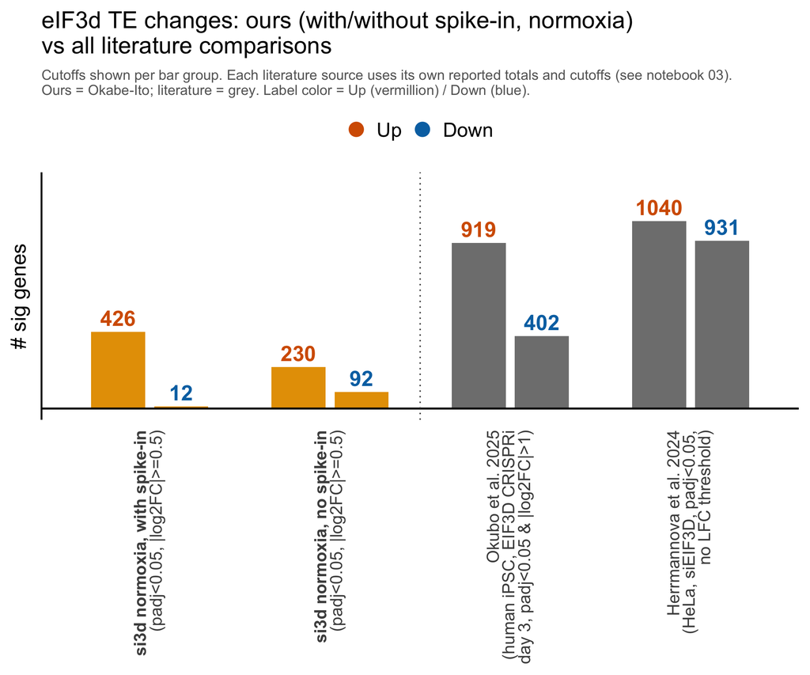

```r
make_target_plot <- function(df, target_label) {
  df <- droplevels(df)
  source_levels_local <- intersect(all_source_levels, levels(df$source))
  n_ours_local <- sum(grepl("^\\*\\*", source_levels_local))
  dodge_local <- position_dodge(width = 0.7)
  y_pad_local <- 0.20 * max(df$n)

  ggplot(df, aes(x = source, y = n, fill = source, group = Direction)) +
    geom_col(position = dodge_local, width = 0.6) +
    geom_text(aes(label = n, color = Direction), position = dodge_local,
              vjust = -0.4, size = 8, fontface = "bold", key_glyph = "point") +
    geom_hline(yintercept = 0, linewidth = 1) +
    geom_vline(xintercept = n_ours_local + 0.5, linetype = "dotted", linewidth = 0.7, color = "grey30") +
    scale_fill_manual(values = source_colors, guide = "none") +
    scale_color_manual(values = c(Up = up_dark, Down = down_dark), name = NULL) +
    scale_y_continuous(limits = c(0, max(df$n) + y_pad_local)) +
    scale_x_discrete(limits = source_levels_local) +
    guides(color = guide_legend(override.aes = list(size = 7))) +
    labs(title = paste0(target_label, " TE changes: ours (with/without spike-in, normoxia)\nvs all literature comparisons"),
         subtitle = "Cutoffs shown per bar group. Each literature source uses its own reported totals and cutoffs (see notebook 03).\nOurs = Okabe-Ito; literature = grey. Label color = Up (vermillion) / Down (blue).",
         x = NULL, y = "# sig genes") +
    theme_classic(base_size = 24) +
    theme(legend.position = "top",
          legend.text = element_text(size = 21),
          plot.title = element_text(size = 25),
          plot.subtitle = element_text(color = "grey40", size = 15),
          axis.line.y = element_line(linewidth = 0.9),
          axis.ticks.y = element_blank(),
          axis.text.y = element_blank(),
          axis.title.y = element_text(size = 22),
          axis.line.x = element_blank(),
          axis.ticks.x = element_blank(),
          axis.text.x = element_markdown(size = 18, angle = 90, hjust = 1, vjust = 0.5))
}

p_all_vs_literature_eif3d <- make_target_plot(all_vs_literature %>% filter(target == "eIF3d"), "eIF3d")
p_all_vs_literature_eif3d
```

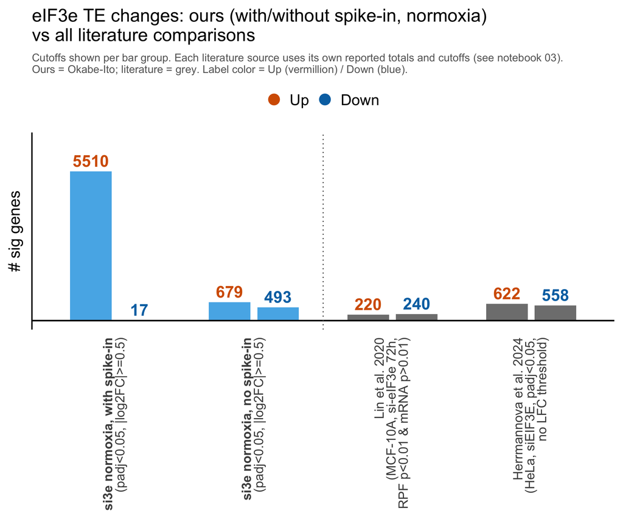

```r
ggsave(here("plots/04_bar_all_vs_literature_eif3d_with_nospike.pdf"), plot = p_all_vs_literature_eif3d, width = 12, height = 10)

p_all_vs_literature_eif3e <- make_target_plot(all_vs_literature %>% filter(target == "eIF3e"), "eIF3e")
p_all_vs_literature_eif3e
```

```r
ggsave(here("plots/04_bar_all_vs_literature_eif3e_with_nospike.pdf"), plot = p_all_vs_literature_eif3e, width = 12, height = 10)
```